# Lab Day 1: regression

Today’s lab meeting consists of three exercises.

Practical information:

- All the data and other files for these exercises can be found at the course platform (i.e., Ulearning platform). Make sure to unzip any .zip files. The folder containing these files will be your working directory.

Short description of exercises:

- The first exercise of today makes an explicit comparison on how certain analyses look in the software you are used to (e.g., SPSS, Excel, Mplus, SAS, or STATA) and how the corresponding analyses look in R when using the lavaan package. The aim is to understand the similarities and differences between software packages. Most exercises include SPSS syntax and Mplus setup.
- The second exercise is aimed at doing a multivariate multiple regression analysis yourself using lavaan. In addition, you will have a look at the ‘technical output’.
- The third exercise is aimed at doing a path analysis yourself using lavaan. Additionally, it will make you familiar with the ‘technical output’.

## Exercise 1: Multiple regression

The data for this exercise is taken from Van de Schoot et al (2010)[^1]. The study examined the understanding of anti-social behaviour and its association with popularity and sociometric status in a sample of at-risk adolescents from diverse ethnic backgrounds (*n* = 1491, average age 14.7 years). Both overt and covert types of anti-social behaviour were used to distinguish subgroups. For the current exercise, you will carry out a regression analysis where you want to predict levels of socially desirable answering patterns of adolescents (*sw*) using the predictors overt (*overt*) and covert antisocial behaviour (*covert*).

**Before you will carry out this regression analysis using lavaan, you will first conduct the analysis in a program of your own choice (SPSS, Mplus, SAS, STATA)**. By first conducting the analysis in another program, you can later check whether the results of lavaan are comparable. If they are the same, you (most certainly) know you specified everything correctly.

In the folder ‘Data files’, you can find four times the corresponding data set, each with a different extension: popular_regr.sav, popular_regr.xlsx, popular_regr_missingsrecoded.dat, and popular_regr.txt. Use the one that fits the software you are used to work with.

Note: There are **missing data** (depending on the file you use, these are coded as system missing, -999, or -99 & -999). Make sure your software recognizes this. In R, one can for example use:

```r
data [sapply(data, function(x) as.character(x) %in% c("-99", "-999") )] <- NA
```

### 1a

Ask for descriptive statistics and run a **correlation** analysis between the variables of interest (*sw, overt* and *covert*). Use your software program of choice.

Note that this is part of your data screening step.

**Click to show answers**

In the subfolders starting with ‘Ex. 1’ in the Solutions folder, you can find the files to perform the analyses in this exercise for SPSS and for Mplus.

Run a (multiple) **regression** analysis (dependent variable (DV) is *sw*; independent variables (IVs) are *covert* and *overt*); also check the standardized results. Use your software program of choice.

**Click to show answers**

In the subfolders starting with ‘Ex. 1’ in the Solutions folder, you can find the files to perform the analyses in this exercise for SPSS and for Mplus.

First, load (and perhaps also install) lavaan. Second, read in the data. Third, denote the missing values.

**Click to show answers**

**Installing Lavaan**

The lavaan package is available on CRAN.Therefore, to install lavaan, simply start up R (studio), and type in the R console:

```r
if (!require("lavaan")) install.packages("lavaan", dependencies = TRUE)
```

Install this package first (once). You can check if the installation was successful by typing:

```r
library(lavaan)
```

A startup message will be displayed showing the version number (always report this in your papers), and a reminder that this is free software. If you see this message, you are ready to start.

**Read in data**

```r
data_regr <- read.table("popular_regr.txt", header = T)
```

If using data without header, then:

```r
colnames(data_regr) <- c("respnr", "Dutch", "gender", "sw", "covert", "overt")
```

**Denote missing values**

-99 and -999 is missing, so set this to NA:

```r
data_regr[sapply(data_regr, function(x) as.character(x) %in% c("-99", "-999") )] <- NA
```

If you forget to tell R that -99 and -999 are used to denote missing data, these values will be treated as being observed.

### 1d

Do the same as in 1a using R.

One could, for example, use the function *describe* from the *psych* package and the *rcorr* function from the *Hmisc* package, respectively.

*Interpret the output. What are your conclusions?*

*What do you think of the correlations with respect to significance, direction, and magnitude?*

**Click to show answers**

**Descriptive statistics**

Variables of interest: *sw, covert,* and *overt*

```r
colnames(data_regr)
```

```
## [1] "respnr" "Dutch"  "gender" "sw"     "covert" "overt"
```

So, columns 4 to 6.

The psych package can be used to obtain some extended summary statistics.

```r
if (!require("psych")) install.packages("psych", dependencies = TRUE)
library(psych)
```

Descriptives like mean, median, min, and max:

```r
describe(data_regr[, 4:6])
```

```
##        vars    n mean   sd median trimmed  mad  min  max range skew kurtosis
## sw        1 1346 3.63 0.68   3.64    3.62 0.67 1.45 5.91  4.45 0.13     0.10
## covert    2 1343 1.94 0.60   2.00    1.92 0.74 1.00 3.75  2.75 0.29    -0.40
## overt     3 1344 1.32 0.37   1.25    1.26 0.37 1.00 3.12  2.12 1.60     2.96
##          se
## sw     0.02
## covert 0.02
## overt  0.01
```

**Correlations**

Correlations for the three variables of interest, incl correlation significance test can be obtained using the rcorr function from the Hmisc package.

```r
if (!require("Hmisc")) install.packages("Hmisc", dependencies = TRUE)
library(Hmisc)
```

```r
res <- rcorr(as.matrix(data_regr[, 4:6])) # rcorr() accepts matrices only
```

Correlation matrix (rounded to 3 decimals):

```r
round(res$r, 3)
```

```
##            sw covert  overt
## sw      1.000 -0.510 -0.334
## covert -0.510  1.000  0.386
## overt  -0.334  0.386  1.000
```

P-values (rounded to 3 decimals):

```r
round(res$P, 3)
```

```
##        sw covert overt
## sw     NA      0     0
## covert  0     NA     0
## overt   0      0    NA
```

Sample size:

```r
res$n
```

```
##          sw covert overt
## sw     1346   1343  1344
## covert 1343   1343  1343
## overt  1344   1343  1344
```

Possible conclusions:

- covert and overt are related to sw, so makes sense (in combination with theory) to use them as predictors.
- Their relationship is negative, so an decrease in (c)overt relates to an increase in sw.
- covert and overt are also related (positively) to each other, but not that much (in absolute sense) that we should worry about multicolinearity.

Do the same as in 1b using R.

One should use the lavaan package, for example, the lavaan function.

*Interpret the output. What are your conclusions?*

*What do you conclude with respect to significance, direction, and magnitude?*

**Click to show answers**

**Specify the regression model**

Now, let us run a multiple regression model predicting levels of socially desirable answering patterns of adolescents (sw) using the predictors overt (overt) and covert antisocial behaviour (covert).

To run a multiple regression with lavaan, you first specify the model, then fit the model and finally acquire the summary. To fit the model we use the lavaan() function, which needs a model= and a data= input.

The model is specified as follows: `dependent ~ predictor1 + predictor2 + etc`

The ~ is like the = in a regression equation.

Before the ~, one states the dependent variable.

After the ~, one states the predictors, each separated by the + sign.

Additionally, one needs to specify that the error (of the dependent variable) has a variance: `dependent ~~ dependent`.

If needed (as is the case here), one can specify to include an intercept: `dependent ~ 1`.

Our regression model is specified as follows:

```r
model.regression <- '
  sw ~ overt + covert # regression
  sw ~~ sw            # residual variance
  sw ~ 1              # intercept
'
```

**Fit the regression model**

```r
fit_regr <- lavaan(model = model.regression, data = data_regr)
```

Note: Instead of specifying intercepts and means in the model, one can include `meanstructure=TRUE` in the lavaan function.

**Output**

```r
summary(fit_regr, fit.measures = TRUE, ci = TRUE, rsquare = TRUE)
```

```
## lavaan 0.6-11 ended normally after 15 iterations
##
##   Estimator                                         ML
##   Optimization method                           NLMINB
##   Number of model parameters                         4
##
##                                                   Used       Total
##   Number of observations                          1343        1491
##
## Model Test User Model:
##
##   Test statistic                                 0.000
##   Degrees of freedom                                 0
##
## Model Test Baseline Model:
##
##   Test statistic                               444.065
##   Degrees of freedom                                 2
##   P-value                                        0.000
##
## User Model versus Baseline Model:
##
##   Comparative Fit Index (CFI)                    1.000
##   Tucker-Lewis Index (TLI)                       1.000
##
## Loglikelihood and Information Criteria:
##
##   Loglikelihood user model (H0)              -1159.083
##   Loglikelihood unrestricted model (H1)      -1159.083
##
##   Akaike (AIC)                                2326.167
##   Bayesian (BIC)                              2346.978
##   Sample-size adjusted Bayesian (BIC)         2334.271
##
## Root Mean Square Error of Approximation:
##
##   RMSEA                                          0.000
##   90 Percent confidence interval - lower         0.000
##   90 Percent confidence interval - upper         0.000
##   P-value RMSEA <= 0.05                             NA
```

[output cut: 13 more lines]

```
##   sw ~
##     overt            -0.292    0.046   -6.381    0.000   -0.381   -0.202
##     covert           -0.507    0.028  -17.866    0.000   -0.563   -0.451
##
## Intercepts:
##                    Estimate  Std.Err  z-value  P(>|z|) ci.lower ci.upper
##    .sw                4.997    0.066   75.581    0.000    4.867    5.126
##
## Variances:
##                    Estimate  Std.Err  z-value  P(>|z|) ci.lower ci.upper
##    .sw                0.329    0.013   25.913    0.000    0.304    0.354
##
## R-Square:
##                    Estimate
##     sw                0.282
```

Can add `standardized=TRUE` to obtain standardized estimates as well.

- Note that the residual variances are denoted by stating a “.” before the variable name. Here: `.sw`
- Note that the intercepts are denoted by stating a “.” before the variable name. Here: `.sw`

**Parameter estimates**

Unstandardized regression parameters

```r
coef(fit_regr)
```

```
##  sw~overt sw~covert    sw~~sw      sw~1
##    -0.292    -0.507     0.329     4.997
```

All unstandardized parameters - with extra information

```r
parameterEstimates(fit_regr)
```

```
##      lhs op    rhs    est    se       z pvalue ci.lower ci.upper
## 1     sw  ~  overt -0.292 0.046  -6.381      0   -0.381   -0.202
## 2     sw  ~ covert -0.507 0.028 -17.866      0   -0.563   -0.451
## 3     sw ~~     sw  0.329 0.013  25.913      0    0.304    0.354
## 4     sw ~1         4.997 0.066  75.581      0    4.867    5.126
## 5  overt ~~  overt  0.138 0.000      NA     NA    0.138    0.138
## 6  overt ~~ covert  0.086 0.000      NA     NA    0.086    0.086
## 7 covert ~~ covert  0.357 0.000      NA     NA    0.357    0.357
## 8  overt ~1         1.325 0.000      NA     NA    1.325    1.325
## 9 covert ~1         1.941 0.000      NA     NA    1.941    1.941
```

All standardized parameters - with extra information

```r
standardizedSolution(fit_regr)
```

```
##      lhs op    rhs est.std    se       z pvalue ci.lower ci.upper
## 1     sw  ~  overt  -0.160 0.025  -6.478      0   -0.208   -0.112
## 2     sw  ~ covert  -0.448 0.022 -20.388      0   -0.491   -0.405
## 3     sw ~~     sw   0.718 0.019  37.255      0    0.681    0.756
## 4     sw ~1          7.384 0.111  66.758      0    7.167    7.601
## 5  overt ~~  overt   1.000 0.000      NA     NA    1.000    1.000
## 6  overt ~~ covert   0.386 0.000      NA     NA    0.386    0.386
## 7 covert ~~ covert   1.000 0.000      NA     NA    1.000    1.000
## 8  overt ~1          3.568 0.000      NA     NA    3.568    3.568
## 9 covert ~1          3.247 0.000      NA     NA    3.247    3.247
```

Note that now you also obtain the confidence interval of the standardized estimates.

**Possible conclusions:**

- The regression equation looks as follows:
  $$sw = 4.997 - 0.292 * overt - 0.507 * covert +
  error$$
- The average sw (levels of socially desirable answering patterns of adolescents) when covert and overt antisocial behaviour are 0 is 4.997;

  When overt goes up with one point, then sw goes down with 0.292 points;

  When covert goes up with one point, then sw goes down with 0.507 points.

  When you are the expert (and look at the scale of the data), you can judge whether these are relevant effects.
- The p-values and confidence intervals indicate that both effects significantly differ from zero. Thus, both variables are (statistically) meaningful predictors.
- The two predictors explain 0.282*100=28.2 percent of sw.
- When looking at the absolute values of the standardized effects, covert is a more important predictor than overt: |-0.448| > |-0.160|.

**Plot**

With lavaanPlot:

```r
if (!require("lavaanPlot")) install.packages("lavaanPlot")
library(lavaanPlot)
lavaanPlot(model = fit_regr,
           node_options = list(shape = "box", fontname = "Helvetica"),
           edge_options = list(color = "grey"), coefs = T, stand = T, covs = T)
```

[interactive chart not shown]

Alternatively, with tidySEM:

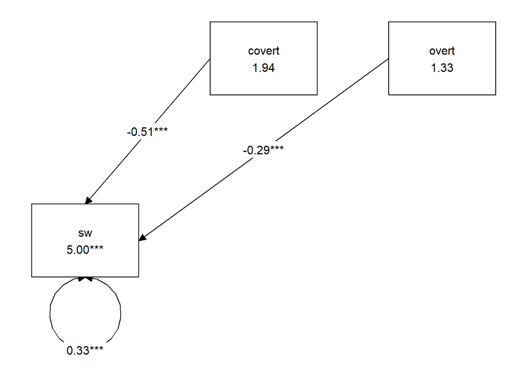

```r
if (!require("tidySEM")) install.packages("tidySEM")
library(tidySEM)
graph_sem(fit_regr)
```

Note: We could/should have also done this before to check whether our model specification seems to be as intended.

**Click to see extra output**

**Fit measures**

Many model fit measures

```r
fitMeasures(fit_regr)
```

```
##                npar                fmin               chisq                  df
##               4.000               0.000               0.000               0.000
##              pvalue      baseline.chisq         baseline.df     baseline.pvalue
##                  NA             444.065               2.000               0.000
##                 cfi                 tli                nnfi                 rfi
##               1.000               1.000               1.000               1.000
##                 nfi                pnfi                 ifi                 rni
##               1.000               0.000               1.000               1.000
##                logl   unrestricted.logl                 aic                 bic
##           -1159.083           -1159.083            2326.167            2346.978
##              ntotal                bic2               rmsea      rmsea.ci.lower
##            1343.000            2334.271               0.000               0.000
##      rmsea.ci.upper        rmsea.pvalue                 rmr          rmr_nomean
##               0.000                  NA               0.000               0.000
##                srmr        srmr_bentler srmr_bentler_nomean                crmr
##               0.000               0.000               0.000               0.000
##         crmr_nomean          srmr_mplus   srmr_mplus_nomean               cn_05
##               0.000               0.000               0.000                  NA
##               cn_01                 gfi                agfi                pgfi
##                  NA               1.000               1.000               0.000
##                 mfi                ecvi
##               1.000               0.006
```

Ask for specific model fit measures

```r
fitMeasures(fit_regr, c("cfi", "tli", "rmsea","srmr"))
```

```
##   cfi   tli rmsea  srmr
##     1     1     0     0
```

R-square (for sw)

```r
inspect(fit_regr, 'r2')
```

```
##    sw
## 0.282
```

**Technical output**

Comparable to TECH1 in Mplus. More details about this in Exercise 3.

```r
lavInspect(fit_regr)
```

```
## $lambda
##        sw overt covert
## sw      0     0      0
## overt   0     0      0
## covert  0     0      0
##
## $theta
##        sw overt covert
## sw     0
## overt  0  0
## covert 0  0     0
##
## $psi
##        sw overt covert
## sw     3
## overt  0  0
## covert 0  0     0
##
## $beta
##        sw overt covert
## sw      0     1      2
## overt   0     0      0
## covert  0     0      0
##
## $nu
##        intrcp
## sw          0
## overt       0
## covert      0
##
## $alpha
##        intrcp
## sw          4
## overt       0
## covert      0
```

**Click to see extra information regarding handling missing data**

**Handling missing data**

Note that in the above listwise deletion is used.From the output, one can see that the total sample size used for the analyses is n=1343, while the total number of observations is 1491.

lavaan used listwise deletion and deleted 148 cases: - 145 cases because of missingness on the dependent variables and - 3 cases because of missingness on the predictors.

The code to use FIML is:

```r
model.regression <- '
  sw ~ overt + covert # regression
  sw ~~ sw            # residual variance
  sw ~ 1              # intercept
  #
  # (co)variances predictors
  overt + covert ~~ overt
  covert ~~ covert
'
fit_regr <- lavaan(model = model.regression, data = data_regr,
                       missing='fiml', fixed.x=F) # Specify FIML
```

Afterwards one can do the same as above. E.g., to get the output:

```r
summary(fit_regr, fit.measures = TRUE, ci = TRUE, rsquare = TRUE)
```

```
## lavaan 0.6-11 ended normally after 36 iterations
##
##   Estimator                                         ML
##   Optimization method                           NLMINB
##   Number of model parameters                         7
##
##                                                   Used       Total
##   Number of observations                          1346        1491
##   Number of missing patterns                         3
##
## Model Test User Model:
##
##   Test statistic                              3874.022
##   Degrees of freedom                                 2
##   P-value (Chi-square)                           0.000
##
## Model Test Baseline Model:
##
##   Test statistic                               661.452
##   Degrees of freedom                                 3
##   P-value                                        0.000
##
## User Model versus Baseline Model:
##
##   Comparative Fit Index (CFI)                    0.000
##   Tucker-Lewis Index (TLI)                      -7.821
##
## Loglikelihood and Information Criteria:
##
##   Loglikelihood user model (H0)              -4781.689
##   Loglikelihood unrestricted model (H1)      -2844.678
##
##   Akaike (AIC)                                9577.378
##   Bayesian (BIC)                              9613.812
##   Sample-size adjusted Bayesian (BIC)         9591.576
##
## Root Mean Square Error of Approximation:
##
##   RMSEA                                          1.199
##   90 Percent confidence interval - lower         1.168
```

[output cut: 24 more lines]

```
## Intercepts:
##                    Estimate  Std.Err  z-value  P(>|z|) ci.lower ci.upper
##    .sw                4.993    0.066   75.456    0.000    4.864    5.123
##     overt             0.000                               0.000    0.000
##     covert            0.000                               0.000    0.000
##
## Variances:
##                    Estimate  Std.Err  z-value  P(>|z|) ci.lower ci.upper
##    .sw                0.329    0.013   25.918    0.000    0.304    0.354
##     overt             1.892    0.073   25.940    0.000    1.749    2.035
##     covert            4.118    0.159   25.940    0.000    3.807    4.429
##
## R-Square:
##                    Estimate
##     sw                0.858
```

**Click to see extra information regarding lavaan notation**

*lavaan notation*

| formula type | operator | mnemonic |
| --- | --- | --- |
| regression | ~ | is regressed on |
| (residual) (co)variance | ~~ | is correlated with |
| intercept | ~ 1 | intercept |
| latent variable definition | =~ | is measured by (Used in other days of the course) |

**General lavaan specification**

*regressions*

y1 + y2 ~ f1 + f2 + x1 + x2

f1 ~ f2 + f3

f2 ~ f3 + x1 + x2

*latent variable definitions*

f1 =~ y1 + y2 + y3

f2 =~ y4 + y5 + y6

f3 =~ y7 + y8 + y9 + y10

*variances and covariances*

y1 ~~ y1

y ~~ y2

f1 ~~ f2

*intercepts*

y1 ~ 1

f1 ~ 1

## Exercise 2: Multivariate regression

In this exercise, we make use of a part (the Child Development Supplement) of the Panel Study of Income Dynamics (PSID)[^2]. The goal is to investigate whether three DVs, Applied problems (*APst02*), Behavioral problems (*Problems*), and Self-esteem (*Selfesteem*), can be predicted from the following two IV’s: digit span (*DS02*) and letters words (*LWst02*). Use the data file **CDSsummerschool.sav** or **CDSsummerschool.txt**.

### 2a

It is a good practice to draw the model you plan to estimate for yourself.

Be very precise in how you draw the correlations.

**Click to show answers**

In the Solutions folder, you can find the file “Ex. 2 - Path diagram.pdf”, which shows such a path diagram.

### 2b

As part of your data screening step, request for descriptive statistics and correlations using R.

Do not forget to read in your data and to denote missing values.

Optional: Check if the descriptive statistics obtained in another software program are comparable.

**Click to show answers**

Notably, the corresponding Mplus in- and output files can be found in the subfolder ‘…\Solutions\Ex.2\Mplus’.

The R code looks as follows:

**Read in data**

```r
data_multivar <- read.table("CDSsummerschool.txt", header = T)
```

**Denote missing values**

-999 is missing, so set this to NA:

```r
data_multivar[sapply(data_multivar, function(x) as.character(x) %in% c("-999") )] <- NA
```

**Descriptive statistics**

Variables of interest: *APst02, Problems, Selfesteem, LWst02, DS02*

```r
colnames(data_multivar)
```

```
## [1] "APst02"     "Problems"   "Selfesteem" "DS02"       "LWst02"
## [6] "GenChild"
```

So, first 5 columns.

The psych package can be used to obtain some extended summary statistics.

```r
if (!require("psych")) install.packages("psych", dependencies = TRUE)
library(psych)
```

Descriptives like mean, median, min, and max:

```r
describe(data_multivar[,1:5])
```

```
## data_multivar[, 1:5]
##
##  5  Variables      3353  Observations
## --------------------------------------------------------------------------------
## APst02
##        n  missing distinct     Info     Mean      Gmd      .05      .10
##     2625      728      111        1    101.9    18.83       76       83
##      .25      .50      .75      .90      .95
##       91      100      113      124      130
##
## lowest :  19  28  41  43  45, highest: 156 160 166 168 171
## --------------------------------------------------------------------------------
## Problems
##        n  missing distinct     Info     Mean      Gmd      .05      .10
##     2868      485       54    0.998    43.11    9.923       33       34
##      .25      .50      .75      .90      .95
##       36       41       48       56       62
##
## lowest : 32 33 34 35 36, highest: 82 84 85 89 94
## --------------------------------------------------------------------------------
## Selfesteem
##        n  missing distinct     Info     Mean      Gmd      .05      .10
##     1724     1629       24    0.993    24.39     4.27       17       19
##      .25      .50      .75      .90      .95
##       22       25       27       29       30
##
## lowest :  6  7  9 10 11, highest: 26 27 28 29 30
## --------------------------------------------------------------------------------
## DS02
##        n  missing distinct     Info     Mean      Gmd      .05      .10
##     2623      730       31    0.995    14.55    4.967        8        9
##      .25      .50      .75      .90      .95
##       12       14       17       21       23
##
## lowest :  0  1  2  3  4, highest: 26 27 28 29 30
## --------------------------------------------------------------------------------
## LWst02
##        n  missing distinct     Info     Mean      Gmd      .05      .10
##     2633      720      130        1    103.6    20.53       77       84
##      .25      .50      .75      .90      .95
##       92      100      114      127      138
##
## lowest :  28  35  36  38  42, highest: 178 179 182 183 184
## --------------------------------------------------------------------------------
```

**Correlations**

Correlations for the five variables of interest, incl correlation significance tests, using the Hmisc package.

```r
if (!require("Hmisc")) install.packages("Hmisc", dependencies = TRUE)
library(Hmisc)
```

```r
res <- rcorr(as.matrix(data_multivar[, 1:5])) # rcorr() accepts matrices only
```

Correlation matrix (rounded to 3 decimals):

```r
round(res$r, 3)
```

```
##            APst02 Problems Selfesteem   DS02 LWst02
## APst02      1.000   -0.228      0.090  0.354  0.582
## Problems   -0.228    1.000     -0.183 -0.150 -0.213
## Selfesteem  0.090   -0.183      1.000  0.095  0.089
## DS02        0.354   -0.150      0.095  1.000  0.356
## LWst02      0.582   -0.213      0.089  0.356  1.000
```

P-values (rounded to 3 decimals):

```r
round(res$P, 3)
```

```
##            APst02 Problems Selfesteem DS02 LWst02
## APst02         NA        0          0    0      0
## Problems        0       NA          0    0      0
## Selfesteem      0        0         NA    0      0
## DS02            0        0          0   NA      0
## LWst02          0        0          0    0     NA
```

Sample size:

```r
res$n
```

```
##            APst02 Problems Selfesteem DS02 LWst02
## APst02       2625     2594       1706 2610   2623
## Problems     2594     2868       1703 2592   2602
## Selfesteem   1706     1703       1724 1706   1711
## DS02         2610     2592       1706 2623   2617
## LWst02       2623     2602       1711 2617   2633
```

### 2c

Create lavaan code to analyze the research question (running a multivariate regression).

In case you closed R after the first exercise, do not forget to load lavaan again.

*Interpret the output. What are your conclusions?*

*Also make sure that you modeled what you intended to model (Hint: Use the function ‘lavInspect()’ and/or a plot)*

**Click to show answers**

**Specify the regression model**

Now, let us run a multivariate regression model predicting Applied problems (*APst02*), Behavioral problems (*Problems*), and Self-esteem (*Selfesteem*), using the predictors digit span (*DS02*) and letters words (*LWst02*).

To run a multivariate regression with lavaan, you first specify the model, then fit the model and finally acquire the summary. To fit the model we use the lavaan() function, which needs a model= and a data= input.

The model specification is comparable to the multiple regression model in exercise 1, but now there are multiple dependent variables. One does not have to specify the regression model for each dependent variable, but one can state the dependent variables separated by the + sign: `dependent1 + dependent2 + dependent3 ~ predictor1 + predictor2 + etc`

The ~ is like the = in a regression equation.

Before the ~, one states the dependent variables, each separated by the + sign.

After the ~, one states the predictors, each separated by the + sign.

Additionally, one needs to specify that the error (of an dependent variable) has a variance: `dependent1 ~~ dependent1`.

And now one also has to specify the residual covariances: `dependent1 ~~ dependent2`.

To specify all the combinations more easily use:

`dependent1 + dependent2 + Selfesteem ~~ dependent1`

`dependent2 + dependent3 ~~ dependent2`

`dependent3 ~~ dependent3`

If needed (as is the case here), one can specify to include intercepts: `dependent1 + dependent2 + dependent3 ~ 1`.

Our regression model is specified as follows:

```r
model.multivar <- '

  # regressions
  APst02 + Problems + Selfesteem ~ DS02 + LWst02

  # residual variances and covariances
  APst02 + Problems + Selfesteem ~~ APst02
  Problems + Selfesteem ~~ Problems
  Selfesteem ~~ Selfesteem

  # variances and covariances of predictors  # *
  DS02 + LWst02 ~~ DS02
  LWst02 ~~ LWst02

  # intercepts / means
  APst02 + Problems + Selfesteem ~ 1  # intercept for each dependent
  DS02 + LWst02 ~ 1                   # means of predictors # *
'
```

*Remark*: This code is not needed to estimate the parameters, but it is needed such that lavaan will count these parameters correctly (see Exercise 3c).

Note: Instead of specifying intercepts and means in the model, one can include ‘meanstructure=TRUE’ in the lavaan function.

**Fit the regression model using the lavaan function:**

```r
if (!require("lavaan")) install.packages("lavaan", dependencies = TRUE)
library(lavaan)
```

`fit_multivar <- lavaan(model = model.multivar, data = data_multivar)`

Because of the missing data, we will use FIML (as explained later in the course):

```r
fit_multivar <- lavaan(model = model.multivar, data = data_multivar,
                       missing='fiml', fixed.x=FALSE) # Specify FIML
```

**Technical output**

```r
lavInspect(fit_multivar)
```

```
## $lambda
##            APst02 Prblms Slfstm DS02 LWst02
## APst02          0      0      0    0      0
## Problems        0      0      0    0      0
## Selfesteem      0      0      0    0      0
## DS02            0      0      0    0      0
## LWst02          0      0      0    0      0
##
## $theta
##            APst02 Prblms Slfstm DS02 LWst02
## APst02     0
## Problems   0      0
## Selfesteem 0      0      0
## DS02       0      0      0      0
## LWst02     0      0      0      0    0
##
## $psi
##            APst02 Prblms Slfstm DS02 LWst02
## APst02      7
## Problems    8     10
## Selfesteem  9     11     12
## DS02        0      0      0     13
## LWst02      0      0      0     14   15
##
## $beta
##            APst02 Prblms Slfstm DS02 LWst02
## APst02          0      0      0    1      2
## Problems        0      0      0    3      4
## Selfesteem      0      0      0    5      6
## DS02            0      0      0    0      0
## LWst02          0      0      0    0      0
##
## $nu
##            intrcp
## APst02          0
## Problems        0
## Selfesteem      0
## DS02            0
## LWst02          0
##
## $alpha
##            intrcp
## APst02         16
## Problems       17
## Selfesteem     18
## DS02           19
## LWst02         20
```

In this output, we can see the numbers 1 to 20. This means that 20 parameters are estimated.

Bear in mind that the values are parameter labels, not parameter values.

Parameters 1 to 6 are the parameters in Beta, which reflects regression coefficients. The rows denote the outcomes and the columns the predictors, thus, in a way, each row denotes a regression equation. For instance, parameter 1 is the regression coefficient of DS02 predicting APst02 (conditional on the other predictor LWst02).

Parameters 7 to 15 are the parameters in psi, where parameters 7 to 12 belong to the outcomes and thus reflect residual (co)variances and parameters 13 to 15 belong to the predictors and thus reflect the (co)variances of the predictors (which will equal the sample (co)variances).

Parameters 16 to 20 are the parameters in alpha, where parameters 16 to 18 belong to the outcomes and thus reflect the intercepts in the regression equation and parameters 19 and 20 belong to the predictors and thus reflect the means of the predictors (which will equal the sample means).

This is indeed the multivariate regression model we intended to fit.

Note that you could also inspect the path diagram of the fitted model for some insight. This is done at the end of this answer section. This you can compare the path diagram your created in Exercise 2a.

**Ouput**

```r
summary(fit_multivar, fit.measures = TRUE, ci = TRUE, rsquare = TRUE)
```

```
## lavaan 0.6-11 ended normally after 90 iterations
##
##   Estimator                                         ML
##   Optimization method                           NLMINB
##   Number of model parameters                        20
##
##                                                   Used       Total
##   Number of observations                          2899        3353
##   Number of missing patterns                        15
##
## Model Test User Model:
##
##   Test statistic                                 0.000
##   Degrees of freedom                                 0
##
## Model Test Baseline Model:
##
##   Test statistic                              1782.895
##   Degrees of freedom                                10
##   P-value                                        0.000
##
## User Model versus Baseline Model:
##
##   Comparative Fit Index (CFI)                    1.000
##   Tucker-Lewis Index (TLI)                       1.000
##
## Loglikelihood and Information Criteria:
##
##   Loglikelihood user model (H0)             -44663.866
##   Loglikelihood unrestricted model (H1)     -44663.866
##
##   Akaike (AIC)                               89367.732
##   Bayesian (BIC)                             89487.175
##   Sample-size adjusted Bayesian (BIC)        89423.627
##
## Root Mean Square Error of Approximation:
##
##   RMSEA                                          0.000
##   90 Percent confidence interval - lower         0.000
##   90 Percent confidence interval - upper         0.000
```

[output cut: 40 more lines]

```
##     LWst02          103.560    0.369  280.803    0.000  102.837  104.282
##
## Variances:
##                    Estimate  Std.Err  z-value  P(>|z|) ci.lower ci.upper
##    .APst02          183.662    5.073   36.202    0.000  173.719  193.606
##    .Problems         83.720    2.223   37.655    0.000   79.362   88.078
##    .Selfesteem       14.590    0.497   29.370    0.000   13.616   15.564
##     DS02             19.996    0.553   36.185    0.000   18.913   21.079
##     LWst02          359.765    9.916   36.279    0.000  340.329  379.201
##
## R-Square:
##                    Estimate
##     APst02            0.365
##     Problems          0.052
##     Selfesteem        0.011
```

- Note that the residual variances are denoted by stating a “.” before the variable name. Here: .APst02, .Problems, and .Selfesteem The variances are denoted without a “.”. Here: DS02 and LWst02
- Note that the intercepts are denoted by stating a “.” before the variable name. Here: .APst02, .Problems, and .Selfesteem The means are denoted without a “.”. Here: DS02 and LWst02

**Parameter estimates**

Unstandardized regression parameters

```r
coef(fit_multivar)
```

```
##            APst02~DS02          APst02~LWst02          Problems~DS02
##                  0.647                  0.468                 -0.180
##        Problems~LWst02        Selfesteem~DS02      Selfesteem~LWst02
##                 -0.091                  0.061                  0.012
##         APst02~~APst02       APst02~~Problems     APst02~~Selfesteem
##                183.662                -15.000                  1.816
##     Problems~~Problems   Problems~~Selfesteem Selfesteem~~Selfesteem
##                 83.720                 -5.721                 14.590
##             DS02~~DS02           DS02~~LWst02         LWst02~~LWst02
##                 19.996                 30.268                359.765
##               APst02~1             Problems~1           Selfesteem~1
##                 44.041                 55.128                 22.197
##                 DS02~1               LWst02~1
##                 14.545                103.560
```

All unstandardized parameters - with extra information

```r
parameterEstimates(fit_multivar)
```

```
##           lhs op        rhs     est    se       z pvalue ci.lower ci.upper
## 1      APst02  ~       DS02   0.647 0.064  10.145  0.000    0.522    0.772
## 2      APst02  ~     LWst02   0.468 0.015  31.264  0.000    0.439    0.497
## 3    Problems  ~       DS02  -0.180 0.043  -4.178  0.000   -0.264   -0.096
## 4    Problems  ~     LWst02  -0.091 0.010  -8.942  0.000   -0.111   -0.071
## 5  Selfesteem  ~       DS02   0.061 0.025   2.423  0.015    0.012    0.110
## 6  Selfesteem  ~     LWst02   0.012 0.005   2.246  0.025    0.002    0.022
## 7      APst02 ~~     APst02 183.662 5.073  36.202  0.000  173.719  193.606
## 8      APst02 ~~   Problems -15.000 2.465  -6.085  0.000  -19.832  -10.169
## 9      APst02 ~~ Selfesteem   1.816 1.298   1.399  0.162   -0.729    4.361
## 10   Problems ~~   Problems  83.720 2.223  37.655  0.000   79.362   88.078
## 11   Problems ~~ Selfesteem  -5.721 0.843  -6.787  0.000   -7.373   -4.069
## 12 Selfesteem ~~ Selfesteem  14.590 0.497  29.370  0.000   13.616   15.564
## 13       DS02 ~~       DS02  19.996 0.553  36.185  0.000   18.913   21.079
## 14       DS02 ~~     LWst02  30.268 1.758  17.214  0.000   26.821   33.714
## 15     LWst02 ~~     LWst02 359.765 9.916  36.279  0.000  340.329  379.201
## 16     APst02 ~1             44.041 1.517  29.028  0.000   41.068   47.015
## 17   Problems ~1             55.128 1.025  53.781  0.000   53.119   57.137
## 18 Selfesteem ~1             22.197 0.508  43.690  0.000   21.201   23.193
## 19       DS02 ~1             14.545 0.087 166.843  0.000   14.374   14.716
## 20     LWst02 ~1            103.560 0.369 280.803  0.000  102.837  104.282
```

All standardized parameters - with extra information

```r
standardizedSolution(fit_multivar)
```

```
##           lhs op        rhs est.std    se       z pvalue ci.lower ci.upper
## 1      APst02  ~       DS02   0.170 0.017  10.219  0.000    0.137    0.203
## 2      APst02  ~     LWst02   0.522 0.015  35.601  0.000    0.493    0.551
## 3    Problems  ~       DS02  -0.086 0.020  -4.188  0.000   -0.126   -0.046
## 4    Problems  ~     LWst02  -0.183 0.020  -9.054  0.000   -0.223   -0.143
## 5  Selfesteem  ~       DS02   0.071 0.029   2.428  0.015    0.014    0.128
## 6  Selfesteem  ~     LWst02   0.059 0.026   2.248  0.025    0.008    0.111
## 7      APst02 ~~     APst02   0.635 0.015  42.370  0.000    0.606    0.665
## 8      APst02 ~~   Problems  -0.121 0.019  -6.214  0.000   -0.159   -0.083
## 9      APst02 ~~ Selfesteem   0.035 0.025   1.401  0.161   -0.014    0.084
## 10   Problems ~~   Problems   0.948 0.009 111.520  0.000    0.931    0.965
## 11   Problems ~~ Selfesteem  -0.164 0.023  -7.011  0.000   -0.209   -0.118
## 12 Selfesteem ~~ Selfesteem   0.989 0.005 196.239  0.000    0.979    0.998
## 13       DS02 ~~       DS02   1.000 0.000      NA     NA    1.000    1.000
## 14       DS02 ~~     LWst02   0.357 0.017  20.939  0.000    0.323    0.390
## 15     LWst02 ~~     LWst02   1.000 0.000      NA     NA    1.000    1.000
## 16     APst02 ~1              2.590 0.116  22.271  0.000    2.362    2.818
## 17   Problems ~1              5.866 0.114  51.568  0.000    5.643    6.089
## 18 Selfesteem ~1              5.778 0.175  32.959  0.000    5.434    6.121
## 19       DS02 ~1              3.253 0.049  66.353  0.000    3.157    3.349
## 20     LWst02 ~1              5.460 0.078  70.231  0.000    5.307    5.612
```

**Fit measures**

Many model fit measures

```r
fitMeasures(fit_multivar)
```

```
##                npar                fmin               chisq                  df
##              20.000               0.000               0.000               0.000
##              pvalue      baseline.chisq         baseline.df     baseline.pvalue
##                  NA            1782.895              10.000               0.000
##                 cfi                 tli                nnfi                 rfi
##               1.000               1.000               1.000               1.000
##                 nfi                pnfi                 ifi                 rni
##               1.000               0.000               1.000               1.000
##                logl   unrestricted.logl                 aic                 bic
##          -44663.866          -44663.866           89367.732           89487.175
##              ntotal                bic2               rmsea      rmsea.ci.lower
##            2899.000           89423.627               0.000               0.000
##      rmsea.ci.upper        rmsea.pvalue                 rmr          rmr_nomean
##               0.000                  NA               0.000               0.000
##                srmr        srmr_bentler srmr_bentler_nomean                crmr
##               0.000               0.000               0.000               0.000
##         crmr_nomean          srmr_mplus   srmr_mplus_nomean               cn_05
##               0.000               0.000               0.000                  NA
##               cn_01                 gfi                agfi                pgfi
##                  NA               1.000               1.000               0.000
##                 mfi                ecvi
##               1.000               0.014
```

R-square for all dependent variables

```r
inspect(fit_multivar, 'r2')
```

```
##     APst02   Problems Selfesteem
##      0.365      0.052      0.011
```

**Possible conclusions:**

- digit span (*DS02*) and letters words (*LWst02*) significantly predict all three outcomes.
- The two predictors positively relate to *APst02* and *Selfesteem* and negatively to *Problems*.
- The two predictors explain 36.5%, 5.2%, and 1.1% of the oucomes *APst02, Problems,* and *Selfesteem*. So, quite a lot of the variance in APst02 is explained. In all, we do miss relevant other predictors.
- When you are the expert (and look at the scale of the data), you can judge whether the effect are relevant or not.
- When looking at the absolute values of the standardized effects, *LWst02* is a more important predictor than *DS02* for *APst02* and *Problems*; while *DS02* is a more (or equally) important predictor than *LWst02* for *Selfesteem*.

Note that the zero chi-square implies that the model is fully saturated: meaning that the theoretical covariance matrix is a function of as manyparameters as there are variances and covariances (on one side of the main diagonal) in the covariance matrix. You have essentially re-interpreted the covariance matrix, and this may be quite meaningful. Then, what you have is essentially a regression model, and you must evaluate your model in those terms:

Are the estimated relationships strong?

Are the direction of the parameter estimates consistent with theory?

Are any assumptions violated (note that this would be checked before analysis)?

Any basic regression text can guide you.

**Plot**

With lavaanPlot:

```r
if (!require("lavaanPlot")) install.packages("lavaanPlot")
library(lavaanPlot)
lavaanPlot(model = fit_multivar,
           node_options = list(shape = "box", fontname = "Helvetica"),
           edge_options = list(color = "grey"), coefs = T, stand = T, covs = T)
```

[interactive chart not shown]

Alternatively, with tidySEM:

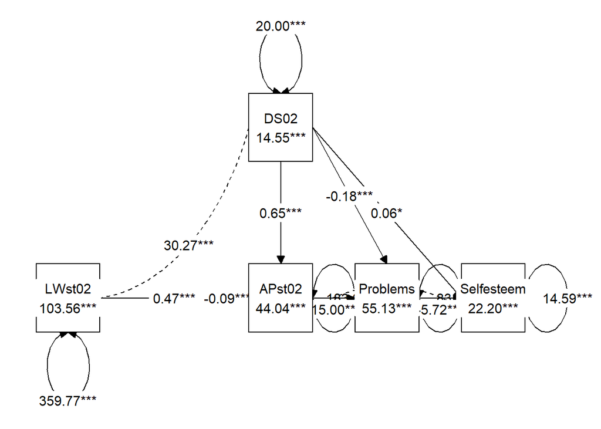

```r
if (!require("tidySEM")) install.packages("tidySEM")
library(tidySEM)
graph_sem(fit_multivar)
```

## Exercise 3: Path analysis

The data for this exercise is about corporal punishment[^3], which can be defined as the deliberate infliction of pain as retribution for an offence, or for the purpose of disciplining or reforming a wrongdoer or to change an undesirable attitude or behavior. Here, we are interested in how corporal punishment influences children’s psychological maladjustment. The data come from 175 children between the ages of 8 and 18. The Physical Punishment Questionnaire (PPQ) was used to measure the level of physical punishment that was experienced.

In this exercise, we focus on predicting psychological *maladjustment* (higher score implies more problems) by perceived *rejection* (e.g., my mother does not really love me; my mother ignores me as long as I do nothing to bother her; my mother goes out of her way to hurt my feelings). Moreover, *rejection* is predicted by perceived *harshness* (0 = never punished physically in any way; 16 = punished more than 12 times a week, very hard) and perceived *justness* (2 = very unfair and almost never deserved; 8 = very fair and almost always deserved).

The data consists of a covariance matrix taken from a published paper and can be found in the file **CorPun.dat** or **CorPun.txt**. Hence, besides analyzing a data set you collected yourself, in lavaan (and Mplus) it is possible to base your analyses on a covariance or correlation table (and this is the reason why reviewers always ask you to include it):

`lower <- scan("CorPun.txt")`

`CovMx <- getCov(lower, names = c("harsh", "just", "reject", "maladj"))`

### 3a

Make a drawing of the statistical model about corporal punishment and write down which parameters (e.g., regression paths, covariances, residuals) you expect to be estimated, and number these parameters.

**Click to show answers**

In the Solutions folder, you can find the file “Ex. 3 - Path diagram.png”, which shows such a path diagram.

**Number of parameters**

The parameters you expect to be estimated:

- 2 x variances (*harsh*, *just*)
- 1 x covariance (*harsh* with *just*)
- 3 x regression paths
- 2 x residual variances (*reject* and *maladj*)
- 2 x means (*just* and *harsh*, if means are available in the data)
- 2 x intercepts (*reject* and *maladj*, if means are available in the data)

Thus, 8 in total without means or 12 with means.

### 3b

Write your lavaan code for this model based on the drawing you made in 3a and run it (after reading in your covariance matrix data).

Note that since you are using a covariance matrix as the input file, you should indicate this - as well as the number of observations - in the lavaan function using:

`sample.cov = <name covariance matrix>`

`sample.nobs = 175`

**Click to show answers**

**Data**

Note: If you have no full dataset, but you do have a sample covariance matrix, you can still fit your model. If you wish to add a mean structure, you need to provide a mean vector too. Importantly, if only sample statistics are provided, you must specify the number of observations that were used to compute the sample moments (`sample.nobs =`). The following example illustrates the use of a sample covariance matrix as input (`sample.cov =`).

**Read in data: a covariance matrix**

```r
lower <- scan("CorPun.txt")
CovMx <- getCov(lower, names = c("harsh", "just", "reject", "maladj"))
```

**Specify the path model**

Now, let us run the model

- predicting psychological maladjustment by perceived rejection.
- predicting rejection by perceived harshness and perceived justness.

Our path model is specified as follows:

```r
model.path <- '

  # regressions
  maladj ~ reject
  reject ~ harsh + just

  # residual variances
  reject ~~ reject
  maladj ~~ maladj
  #
  # variances and covariances of predictors # *
  harsh + just ~~ harsh
  just ~~ just

  ## intercepts - if we would have mean value as input too
  ## or use meanstructure=TRUE in the lavaan function
  #maladj ~ 1
  #reject ~ 1
'
```

*Remark*: This code is not needed to estimate the parameters, but it is needed such that lavaan will count these parameters correctly (see Exercise 3c).

**Fit the regression model using the lavaan function:**

```r
if (!require("lavaan")) install.packages("lavaan", dependencies = TRUE)
library(lavaan)
```

```r
fit_path <- lavaan(model = model.path,
                       sample.cov = CovMx, # Now, using a covariance matrix as input
                       sample.nobs = 175) # In that case, the sample size is needed as well
```

### 3c

Ask for the technical output to inspect which parameters are estimated. For a lavaan fit object, use the function `lavInspect()`. Note that this comparable to asking for the TECH1 output in Mplus.

In this output, you can find six matrices (nu, lambda, theta, alpha, beta, and psi) with numbers summing up to the total number of parameters that are estimated. This way you can check whether you analyzed the model you wanted (and you will discover this is not always the case).

*Which of the parameters you listed in Exercise 3a should be in which matrix?*  
For example: the regression coefficient between *rejection* and *harshness* should be in the Beta matrix. Write this down for each parameter.

*Did you estimate all the parameters that you expected? If not, what should be changed to the input?*

- A first check is to see whether ‘Number of model parameters’ equals the number of elements in your variance-covariance matrix and if available the means.
- You can count the number of elements in your variance-covariance matrix:

  number of variables * (number of variables +1) / 2.
- If you also have means, ‘Number of model parameters’ should equal the number of elements in your variance-covariance matrix plus the number of variables.
- Thus, for our four variables without means, the calculation is: 4*5/2=10.
- If we would have means, the number of sample statistics would be 14 (i.e., 4*5/2 +4).

Notice that you can also answer this question by means of a plot: e.g., using `lavaanPlot()` from the lavaanPlot package or `graph_sem()` from the tidysem package. This will show you all (means, intercepts,) regression paths, (residual) variances, and covariances. Notably, `lavaanPlot()` will not provide you with information about the means and intercepts (i.e., the nu & alpha matrices) nor the residual (co)variances.

**Click to show answers**

**Technical output**

```r
lavInspect(fit_path)
```

```
## $lambda
##        maladj reject harsh just
## maladj      0      0     0    0
## reject      0      0     0    0
## harsh       0      0     0    0
## just        0      0     0    0
##
## $theta
##        maladj reject harsh just
## maladj 0
## reject 0      0
## harsh  0      0      0
## just   0      0      0     0
##
## $psi
##        maladj reject harsh just
## maladj 5
## reject 0      4
## harsh  0      0      6
## just   0      0      7     8
##
## $beta
##        maladj reject harsh just
## maladj      0      1     0    0
## reject      0      0     2    3
## harsh       0      0     0    0
## just        0      0     0    0
```

This returns a list of the model matrices that are used internally to represent the model.

Which parameter is listed in which matrix:

The regression coefficients belong in the Beta matrix, the variances and residual variances in the Psi matrix. If you specified them!

Note (related to *Remark* in Exercises 2c and 3b): When there is no specification of the variances of harsh and just and their covariance, the technical output (here, Psi) indicates that these 3 parameters are not estimated. Like in Mplus, this does not affect the degrees of freedom and thus the test result! In case you want to check this, run:

```r
model.path_check <- '

  # regressions
  maladj ~ reject
  reject ~ harsh + just

  # residual variances
  reject ~~ reject
  maladj ~~ maladj
  #
  # Check: Not specifying these variances and covariances
  # variances and covariances of predictors # *
  #harsh + just ~~ harsh
  #just ~~ just

  ## intercepts - if we would have mean value as input too
  ## or use meanstructure=TRUE in the lavaan function
  #maladj ~ 1
  #reject ~ 1
'
fit_path_check <- lavaan(model = model.path_check,
                   sample.cov = CovMx, # Now, using a covariance matrix as input
                   sample.nobs = 175) # In that case, the sample size is needed as well
summary(fit_path_check, fit.measures = TRUE, ci = TRUE, rsquare = TRUE)
```

```
## lavaan 0.6-11 ended normally after 1 iterations
##
##   Estimator                                         ML
##   Optimization method                           NLMINB
##   Number of model parameters                         5
##
##   Number of observations                           175
##
## Model Test User Model:
##
##   Test statistic                                 1.546
##   Degrees of freedom                                 2
##   P-value (Chi-square)                           0.462
##
## Model Test Baseline Model:
##
##   Test statistic                               101.641
##   Degrees of freedom                                 5
##   P-value                                        0.000
##
## User Model versus Baseline Model:
##
##   Comparative Fit Index (CFI)                    1.000
##   Tucker-Lewis Index (TLI)                       1.012
##
## Loglikelihood and Information Criteria:
##
##   Loglikelihood user model (H0)              -1429.415
##   Loglikelihood unrestricted model (H1)      -1428.642
##
##   Akaike (AIC)                                2868.831
##   Bayesian (BIC)                              2884.655
##   Sample-size adjusted Bayesian (BIC)         2868.821
##
## Root Mean Square Error of Approximation:
##
##   RMSEA                                          0.000
##   90 Percent confidence interval - lower         0.000
##   90 Percent confidence interval - upper         0.139
##   P-value RMSEA <= 0.05                          0.598
```

[output cut: 13 more lines]

```
##   maladj ~
##     reject            0.387    0.051    7.658    0.000    0.288    0.486
##   reject ~
##     harsh             2.607    0.584    4.462    0.000    1.462    3.753
##     just             -4.396    0.763   -5.758    0.000   -5.892   -2.899
##
## Variances:
##                    Estimate  Std.Err  z-value  P(>|z|) ci.lower ci.upper
##    .reject          268.213   28.673    9.354    0.000  212.015  324.411
##    .maladj          158.958   16.993    9.354    0.000  125.652  192.264
##
## R-Square:
##                    Estimate
##     reject            0.246
##     maladj            0.251
```

```r
lavInspect(fit_path_check)
```

```
## $lambda
##        maladj reject harsh just
## maladj      0      0     0    0
## reject      0      0     0    0
## harsh       0      0     0    0
## just        0      0     0    0
##
## $theta
##        maladj reject harsh just
## maladj 0
## reject 0      0
## harsh  0      0      0
## just   0      0      0     0
##
## $psi
##        maladj reject harsh just
## maladj 5
## reject 0      4
## harsh  0      0      0
## just   0      0      0     0
##
## $beta
##        maladj reject harsh just
## maladj      0      1     0    0
## reject      0      0     2    3
## harsh       0      0     0    0
## just        0      0     0    0
```

Hence, always cross check that lavaan has understood what you wanted it to do by looking at the model degrees of freedom, the technical output (even the starting values) and model results. When these pieces of information do not contradict each other and lavaan gives you exactly the output you expect, then you can move forward with interpreting the model effects.

**Plot**

With lavaanPlot:

```r
if (!require("lavaanPlot")) install.packages("lavaanPlot")
library(lavaanPlot)
lavaanPlot(model = fit_path,
           node_options = list(shape = "box", fontname = "Helvetica"),
           edge_options = list(color = "grey"), coefs = T, stand = T, covs = T)
```

[interactive chart not shown]

Alternatively, with tidySEM:

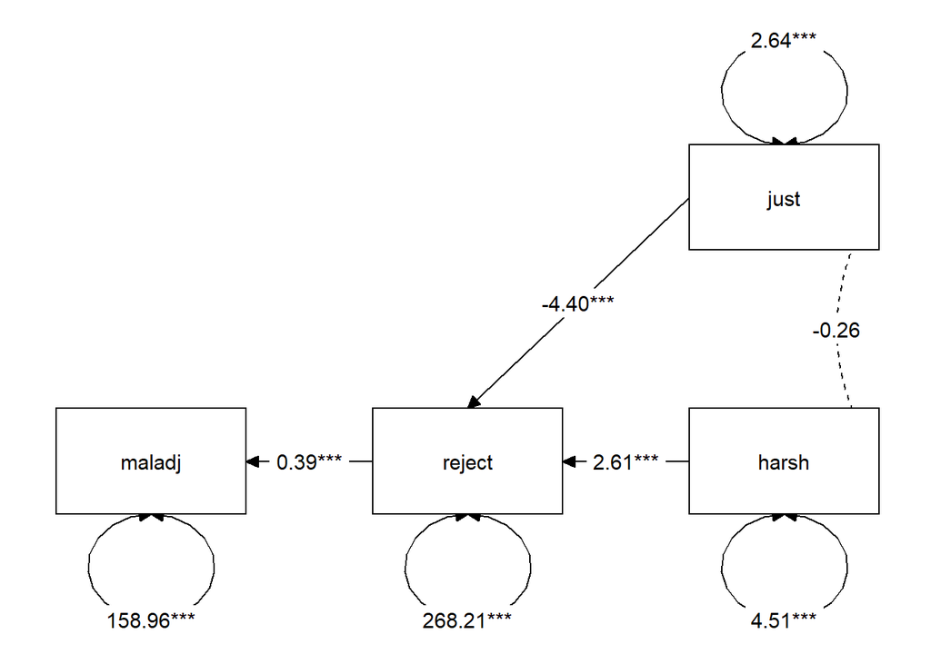

```r
if (!require("tidySEM")) install.packages("tidySEM")
library(tidySEM)
graph_sem(fit_path)
```

### 3d

Interpret the output.

*Write down the chi-square statistic and its degrees of freedom from the model fit information. Also inspect other model fit measures.*

**Click to show answers**

**Output**

```r
summary(fit_path, fit.measures = TRUE, ci = TRUE, rsquare = TRUE)
```

```
## lavaan 0.6-11 ended normally after 14 iterations
##
##   Estimator                                         ML
##   Optimization method                           NLMINB
##   Number of model parameters                         8
##
##   Number of observations                           175
##
## Model Test User Model:
##
##   Test statistic                                 1.546
##   Degrees of freedom                                 2
##   P-value (Chi-square)                           0.462
##
## Model Test Baseline Model:
##
##   Test statistic                               102.623
##   Degrees of freedom                                 6
##   P-value                                        0.000
##
## User Model versus Baseline Model:
##
##   Comparative Fit Index (CFI)                    1.000
##   Tucker-Lewis Index (TLI)                       1.014
##
## Loglikelihood and Information Criteria:
##
##   Loglikelihood user model (H0)              -2142.534
##   Loglikelihood unrestricted model (H1)      -2141.761
##
##   Akaike (AIC)                                4301.069
##   Bayesian (BIC)                              4326.387
##   Sample-size adjusted Bayesian (BIC)         4301.054
##
## Root Mean Square Error of Approximation:
##
##   RMSEA                                          0.000
##   90 Percent confidence interval - lower         0.000
##   90 Percent confidence interval - upper         0.139
##   P-value RMSEA <= 0.05                          0.598
```

[output cut: 20 more lines]

```
##                    Estimate  Std.Err  z-value  P(>|z|) ci.lower ci.upper
##   harsh ~~
##     just             -0.259    0.262   -0.987    0.324   -0.772    0.255
##
## Variances:
##                    Estimate  Std.Err  z-value  P(>|z|) ci.lower ci.upper
##    .reject          268.213   28.673    9.354    0.000  212.015  324.411
##    .maladj          158.958   16.993    9.354    0.000  125.652  192.264
##     harsh             4.514    0.483    9.354    0.000    3.568    5.460
##     just              2.645    0.283    9.354    0.000    2.091    3.199
##
## R-Square:
##                    Estimate
##     reject            0.246
##     maladj            0.251
```

Note that the residual variances are denoted by stating a “.” before the variable name of the outcome / endogenous variable. Here: .reject and .maladj

The variances are denoted without a “.”, so just the variable name of the predictor / exogenous variable. Here: harsh and just

- The chi-square statistic and its degrees of freedom:

`Model Test User Model:`

`Test statistic 1.546`

`Degrees of freedom 2`

`P-value (Chi-square) 0.462`

**Parameter estimates**

Unstandardized regression parameters

```r
coef(fit_path)
```

```
##  maladj~reject   reject~harsh    reject~just reject~~reject maladj~~maladj
##          0.387          2.607         -4.396        268.213        158.958
##   harsh~~harsh    harsh~~just     just~~just
##          4.514         -0.259          2.645
```

All unstandardized parameters - with extra information

```r
parameterEstimates(fit_path)
```

```
##      lhs op    rhs     est     se      z pvalue ci.lower ci.upper
## 1 maladj  ~ reject   0.387  0.051  7.658  0.000    0.288    0.486
## 2 reject  ~  harsh   2.607  0.584  4.462  0.000    1.462    3.753
## 3 reject  ~   just  -4.396  0.763 -5.758  0.000   -5.892   -2.899
## 4 reject ~~ reject 268.213 28.673  9.354  0.000  212.015  324.411
## 5 maladj ~~ maladj 158.958 16.993  9.354  0.000  125.652  192.264
## 6  harsh ~~  harsh   4.514  0.483  9.354  0.000    3.568    5.460
## 7  harsh ~~   just  -0.259  0.262 -0.987  0.324   -0.772    0.255
## 8   just ~~   just   2.645  0.283  9.354  0.000    2.091    3.199
```

All standardized parameters - with extra information

```r
standardizedSolution(fit_path)
```

```
##      lhs op    rhs est.std    se      z pvalue ci.lower ci.upper
## 1 maladj  ~ reject   0.501 0.057  8.849   0.00    0.390    0.612
## 2 reject  ~  harsh   0.294 0.063  4.626   0.00    0.169    0.418
## 3 reject  ~   just  -0.379 0.062 -6.161   0.00   -0.499   -0.258
## 4 reject ~~ reject   0.754 0.057 13.324   0.00    0.643    0.864
## 5 maladj ~~ maladj   0.749 0.057 13.202   0.00    0.638    0.860
## 6  harsh ~~  harsh   1.000 0.000     NA     NA    1.000    1.000
## 7  harsh ~~   just  -0.075 0.075 -0.995   0.32   -0.222    0.073
## 8   just ~~   just   1.000 0.000     NA     NA    1.000    1.000
```

**Fit measures**

Many model fit measures

```r
fitMeasures(fit_path)
```

```
##                npar                fmin               chisq                  df
##               8.000               0.004               1.546               2.000
##              pvalue      baseline.chisq         baseline.df     baseline.pvalue
##               0.462             102.623               6.000               0.000
##                 cfi                 tli                nnfi                 rfi
##               1.000               1.014               1.014               0.955
##                 nfi                pnfi                 ifi                 rni
##               0.985               0.328               1.005               1.005
##                logl   unrestricted.logl                 aic                 bic
##           -2142.534           -2141.761            4301.069            4326.387
##              ntotal                bic2               rmsea      rmsea.ci.lower
##             175.000            4301.054               0.000               0.000
##      rmsea.ci.upper        rmsea.pvalue                 rmr          rmr_nomean
##               0.139               0.598               0.558               0.558
##                srmr        srmr_bentler srmr_bentler_nomean                crmr
##               0.023               0.023               0.023               0.030
##         crmr_nomean          srmr_mplus   srmr_mplus_nomean               cn_05
##               0.030               0.023               0.023             679.189
##               cn_01                 gfi                agfi                pgfi
##            1043.541               0.996               0.978               0.199
##                 mfi                ecvi
##               1.001               0.100
```

Ask for specific model fit measures

```r
fitMeasures(fit_path, c("cfi", "tli", "rmsea","srmr"))
```

```
##   cfi   tli rmsea  srmr
## 1.000 1.014 0.000 0.023
```

- Model chi-square is the chi-square statistic obtained from the maximum likelihood statistic. (in lavaan: ‘the Test Statistic for the Model Test User Model’)
- CFI is the Comparative Fit Index. Values can range between 0 and 1 (values greater than 0.90, conservatively 0.95 indicate good fit)
- TLI Tucker Lewis Index which also ranges between 0 and 1(if it’s greater than 1 it should be rounded to 1) with values greater than 0.90 indicating good fit. If the CFI and TLI are less than one, the CFI is always greater than the TLI.
- RMSEA is the root mean square error of approximation. In lavaan, you also obtain a p-value of close fit, that the RMSEA < 0.05. If you reject the model, it means your model is not a close fitting model.

R-square for all dependent variables:

```r
inspect(fit_path, 'r2')
```

```
## reject maladj
##  0.246  0.251
```

[^1]: Van de Schoot, R., Van der Velden, F., Boom, J., & Brugman, D. (2010). Can at-risk young adolescents be popular and anti-social? Sociometric status groups, anti-social behavior, gender and ethnic background. Journal of Adolescence, 33(5), 583-592. doi:10.1016/j.adolescence.2009.12.004
[^2]: Produced and distributed by the Institute for Social Research, Survey Research Center, University of Michigan, Ann Arbor, MI
[^3]: Rohner, R. P., Bourque, S. L., & Elordi, C. A. (1996). Children’s perceptions of corporal punishment, caretaker acceptance, and psychological adjustment in a poor, biracial southern community. Journal of Marriage and the Family, 58, 842-852.